# Avoid text overlap

Example using data from Sinharaja

maurolepore@gmail.com

2017-09-20

# Goal

To clearly plot information that help workers to identify specific trees on the field. Previous drafts were too crowded, with labels that overlapped and impaired reading the information clearly.

For each quadrat we want to output 4 plots, each showing 1/4 of the quadrat’s area. Each of those sub-quadrat we want to plot in one separate page.

# Approach

- Overview the entire data to understand it.
- Pull one data frame.
  - Overview it.
  - Draft a plot quickly to see it we are heading in the right direction.
  - Divide it in 4 subplots.
  - Plot avoiding labels overploting.
    - aesthetics:
      - `x`, `y` map to position in the quadrat, i.e. `lx`, `ly`.
      - text maps to `tag` id
      - shape or colour map to symbol

# Explore entire data set

> (To Stuart) Since there are 67 quadrats in your check list there will be 268 pages (4 per quad) –Shameema

The name of each data frame, and their number (67) confirm they correspond to the name (or ID) of each quadrat.

```r
names(sin_q20)
```

```
#>  [1] "15"   "16"   "18"   "103"  "104"  "105"  "109"  "114"  "115"  "116"
#> [11] "117"  "118"  "214"  "307"  "311"  "312"  "313"  "314"  "315"  "406"
#> [21] "407"  "408"  "412"  "413"  "414"  "422"  "614"  "618"  "713"  "722"
#> [31] "723"  "1113" "1114" "1115" "1213" "1214" "1215" "1223" "1313" "1314"
#> [41] "1315" "1600" "1708" "1900" "1901" "2004" "2011" "2014" "2102" "2105"
#> [51] "2106" "2116" "2117" "2124" "2202" "2206" "2207" "2208" "2302" "2305"
#> [61] "2306" "2307" "2318" "2401" "2402" "2406" "2420"
```

Let’s confirm that all 67 data frames in the list have the same variable names.

```r
# Yes. All data frames have exactly the same name.
unique(lapply(sin_q20, names))
```

```
#> [[1]]
#> [1] "tag"    "lx"     "ly"     "subtag" "status" "symbol"
```

Now let’s overview the data set, paying special attention to the type of each variable.

```r
# Show only part of the entire data set to save space
n_cols_per_df <- unlist(unique(lapply(sin_q20, ncol)))
str(sin_q20[1:3])
```

```
#> List of 3
#>  $ 15:'data.frame':  323 obs. of  6 variables:
#>   ..$ tag   : int [1:323] 4193 4194 4195 4196 4197 4198 4199 4200 4201 4202 ...
#>   ..$ lx    : num [1:323] 2.1 1 1.1 1.9 1.8 2 2.4 4.2 5.7 5.2 ...
#>   ..$ ly    : num [1:323] 0.5 1.6 1.8 1.2 1.5 3.2 0.7 2 3.5 4.5 ...
#>   ..$ subtag: int [1:323] 193 194 195 196 197 198 199 200 201 202 ...
#>   ..$ status: Factor w/ 5 levels "alive","broken below",..: 1 5 1 5 5 5 5 5 5 2 ...
#>   ..$ symbol: int [1:323] 16 16 16 16 16 16 16 16 16 16 ...
#>  $ 16:'data.frame':  362 obs. of  6 variables:
#>   ..$ tag   : int [1:362] 4477 4478 4479 4480 4481 4482 4483 4484 4485 4486 ...
#>   ..$ lx    : num [1:362] 4.4 4.5 0.6 0.8 1 0.3 2.8 4.6 1.1 2.6 ...
#>   ..$ ly    : num [1:362] 0.2 0.9 0.5 1.5 3 3.3 3.6 2.2 4 4.5 ...
#>   ..$ subtag: int [1:362] 477 478 479 480 481 482 483 484 485 486 ...
#>   ..$ status: Factor w/ 5 levels "alive","broken below",..: 1 5 3 3 2 2 3 1 5 5 ...
#>   ..$ symbol: int [1:362] 16 16 1 0 16 16 0 16 16 16 ...
#>  $ 18:'data.frame':  496 obs. of  6 variables:
#>   ..$ tag   : int [1:496] 5162 5163 5164 5165 5166 5167 5168 5169 5170 5171 ...
#>   ..$ lx    : num [1:496] 0.2 1.6 2 0.6 0.4 1.3 0.3 1.4 1.9 2.2 ...
#>   ..$ ly    : num [1:496] 0 1.2 2.4 2.8 4 4.6 5.2 4.7 4.4 5.2 ...
#>   ..$ subtag: int [1:496] 162 163 164 165 166 167 168 169 170 171 ...
#>   ..$ status: Factor w/ 5 levels "alive","broken below",..: 1 1 3 1 1 3 1 1 3 1 ...
#>   ..$ symbol: int [1:496] 16 16 15 16 16 1 16 16 0 16 ...
```

`status` should probabbly be a character variable (data dictionary https://goo.gl/i6kHiQ) but here it is a factor.

```r
# map() is like lapply with some handy shortcuts
map(sin_q20, "status") %>%
  map(unique) %>%
  head()
```

```
#> $`15`
#> [1] alive        stem dead    broken below dead
#> Levels: alive broken below dead missing stem dead
#>
#> $`16`
#> [1] alive        stem dead    dead         broken below
#> Levels: alive broken below dead missing stem dead
#>
#> $`18`
#> [1] alive        dead         stem dead    broken below
#> Levels: alive broken below dead missing stem dead
#>
#> $`103`
#> [1] alive        dead         broken below stem dead
#> Levels: alive broken below dead missing stem dead
#>
#> $`104`
#> [1] alive        dead         broken below stem dead
#> Levels: alive broken below dead missing stem dead
#>
#> $`105`
#> [1] alive        stem dead    broken below dead
#> Levels: alive broken below dead missing stem dead
```

The reason why `status` is a factor is probably because the data frames where built using the default `stringsAsFactors = TRUE`. Because it may cause problems, let’s fix this now. We’ll also take the chance to convert the variable `symbol` to a factor. This will later make plotting easier.

```r
convert_status_to_character <- function(x) {
  x$status <- as.character(x$status)
  x
}
convert_symbol_to_factor <- function(x) {
  x$symbol <- as.factor(x$symbol)
  x
}
sin_q20 <- lapply(sin_q20, convert_status_to_character)
sin_q20 <- lapply(sin_q20, convert_symbol_to_factor)

# Showing only a few data frames to save space
str(sin_q20[1:3])
```

```
#> List of 3
#>  $ 15:'data.frame':  323 obs. of  6 variables:
#>   ..$ tag   : int [1:323] 4193 4194 4195 4196 4197 4198 4199 4200 4201 4202 ...
#>   ..$ lx    : num [1:323] 2.1 1 1.1 1.9 1.8 2 2.4 4.2 5.7 5.2 ...
#>   ..$ ly    : num [1:323] 0.5 1.6 1.8 1.2 1.5 3.2 0.7 2 3.5 4.5 ...
#>   ..$ subtag: int [1:323] 193 194 195 196 197 198 199 200 201 202 ...
#>   ..$ status: chr [1:323] "alive" "stem dead" "alive" "stem dead" ...
#>   ..$ symbol: Factor w/ 4 levels "0","1","15","16": 4 4 4 4 4 4 4 4 4 4 ...
#>  $ 16:'data.frame':  362 obs. of  6 variables:
#>   ..$ tag   : int [1:362] 4477 4478 4479 4480 4481 4482 4483 4484 4485 4486 ...
#>   ..$ lx    : num [1:362] 4.4 4.5 0.6 0.8 1 0.3 2.8 4.6 1.1 2.6 ...
#>   ..$ ly    : num [1:362] 0.2 0.9 0.5 1.5 3 3.3 3.6 2.2 4 4.5 ...
#>   ..$ subtag: int [1:362] 477 478 479 480 481 482 483 484 485 486 ...
#>   ..$ status: chr [1:362] "alive" "stem dead" "dead" "dead" ...
#>   ..$ symbol: Factor w/ 4 levels "0","1","15","16": 4 4 2 1 4 4 1 4 4 4 ...
#>  $ 18:'data.frame':  496 obs. of  6 variables:
#>   ..$ tag   : int [1:496] 5162 5163 5164 5165 5166 5167 5168 5169 5170 5171 ...
#>   ..$ lx    : num [1:496] 0.2 1.6 2 0.6 0.4 1.3 0.3 1.4 1.9 2.2 ...
#>   ..$ ly    : num [1:496] 0 1.2 2.4 2.8 4 4.6 5.2 4.7 4.4 5.2 ...
#>   ..$ subtag: int [1:496] 162 163 164 165 166 167 168 169 170 171 ...
#>   ..$ status: chr [1:496] "alive" "alive" "dead" "alive" ...
#>   ..$ symbol: Factor w/ 4 levels "0","1","15","16": 4 4 3 4 4 2 4 4 1 4 ...
```

These are the values of the variable `symbol`:

```r
sin_q20[[1]]$symbol %>% unique()
```

```
#> [1] 16 15 0  1
#> Levels: 0 1 15 16
```

This is what they mean (after email by Shameema , https://goo.gl/S8KfWf):

- 16: filled circles on a map indicate trees that are alive in census4.
- 1: open circles indicate trees that were alive in census 3 but were found dead in census 4.
- 15: filled squares indicate trees that were alive in census 2 but did not survive to census 3.
- 0: open squares indicate trees that were alive in census 1 but did not live to census 2.

To make this easier to interpret, I’ll use more explicit values.

```r
# Add alternatives to symbol, that are easier to understand
codify_explicitely <- function(x) {
  mutate(x,
    sym1 = case_when(
      symbol == 16 ~ "Alive in 4",
      symbol ==  1 ~ "Alive in 3, Dead in 4",
      symbol == 15 ~ "Alive in 2, Dead in 3",
      symbol ==  0 ~ "Alive in 1, Dead in 2"
    ),
    sym2 = case_when(
      symbol == 16 ~ "(4. )",
      symbol ==  1 ~ "(3.4)",
      symbol == 15 ~ "(2.3)",
      symbol ==  0 ~ "(1.2)"
    )
  )
}
sin_q20 <- map(sin_q20, codify_explicitely)
```

# Plot

Lets filter the lower left quarter of one quadrat and plot it. Later I can apply the same approach to all other quarters of each quadrat, and to all other quadrats.

From the entire data set, pull out only one data frame and overview it.

```r
# Filter lower left subsection
first_df <- as.tibble(sin_q20[[1]])
first_ll <- filter(first_df, lx <= 10, ly <= 10)
```

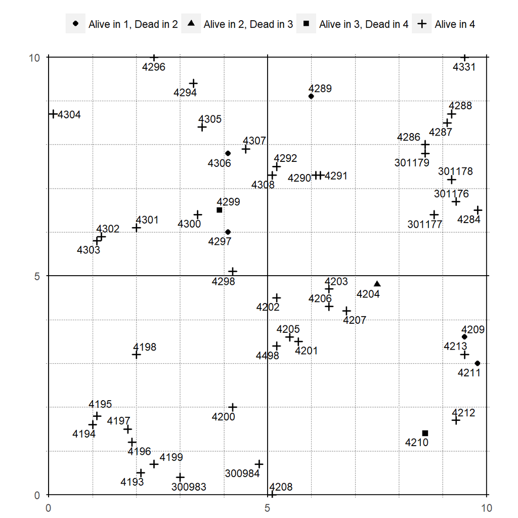

```r
# Tweak plot
point_size <- 1.5
id_size <- 3
shrink <- c(0.4, 9.6)

theme <- theme(
  panel.grid.major = element_line(colour = "black"),
  panel.grid.minor = element_line(linetype = "dotted", colour = "black"),
  panel.background = element_rect(fill = 'white'),
  legend.position = "top",
  axis.ticks = element_blank(),
  legend.title = element_blank(),
  # panel.border = element_rect(linetype = "dashed", fill = NA)
  )

plot_repel <- function(df) {
  ggplot(df, aes(x = lx, y = ly, shape = sym1)) +
    geom_point(size = point_size) +
    geom_text_repel(aes(label = tag), size = id_size) +
    scale_x_continuous(minor_breaks = seq(1, 20, 1), breaks = seq(0, 20, 5)) +
    scale_y_continuous(minor_breaks = seq(1, 20, 1), breaks = seq(0, 20, 5)) +
    coord_fixed(xlim = shrink, ylim = shrink) +
    labs(x = NULL, y = NULL) +
    theme
}
p <- plot_repel(first_ll)
p
```

Check that the values of `symbol` make sense:

```r
first_df %>%
  select(status, symbol, sym1, sym2) %>%
  unique()
```

```
#> # A tibble: 6 x 4
#>         status symbol                  sym1  sym2
#>          <chr> <fctr>                 <chr> <chr>
#> 1        alive     16            Alive in 4 (4. )
#> 2    stem dead     16            Alive in 4 (4. )
#> 3 broken below     16            Alive in 4 (4. )
#> 4         dead     15 Alive in 2, Dead in 3 (2.3)
#> 5         dead      0 Alive in 1, Dead in 2 (1.2)
#> 6         dead      1 Alive in 3, Dead in 4 (3.4)
```

```r
# symbol means:
# * 16: filled circles on a map indicate trees that are alive in census4.
# *  1: open circles indicate trees that were alive in census 3 but were found
#       dead in census 4.
# * 15: filled squares indicate trees that were alive in census 2 but did not
#       survive to census 3.
# *  0: open squares indicate trees that were alive in census 1 but did not
#       live to census 2.
# (after email by Shameema , https://goo.gl/S8KfWf)
```